# Titanic Survival Analysis

Christopher Castle

This analysis was originally derived from an online tutorial at TrevorStephens.com which was a very useful introduction to some of these concepts. Since then I’ve continued working with this script and modified it substantially.

We’ll begin by combining the train and test data sets for feature modification. We’ll start by separating passengers’ titles from their names and then create a feature for the size of their family onboard.

```r
# Join together the test and train to create new variable
test$Survived <- NA
all<- rbind(train, test)

# Convert to a string
all$Name <- as.character(all$Name)

# Engineered variable: Title
all$Title <- sapply(all$Name, FUN=function(x) {strsplit(x, split='[,.]')[[1]][2]})
all$Title <- sub(' ', '', all$Title)
# combine small title groups
all$Title[all$Title %in% c('Mme', 'Mlle')] <- 'Mlle'
all$Title[all$Title %in% c('Capt', 'Don', 'Major', 'Sir', 'Jonkheer')] <- 'Sir'
all$Title[all$Title %in% c('Dona', 'Lady', 'the Countess')] <- 'Lady'

# Convert to a factor
all$Title <- factor(all$Title)

# Engineered variable: Family size
all$FamilySize <- all$SibSp + all$Parch + 1

# Engineered variable: Family
all$Surname <- sapply(all$Name, FUN=function(x) {strsplit(x, split='[,.]')[[1]][1]})
all$FamilyID <- paste(as.character(all$FamilySize), all$Surname, sep="")
all$FamilyID[all$FamilySize <= 2] <- 'Small'
# Delete erroneous family IDs
famIDs <- data.frame(table(all$FamilyID))
famIDs <- famIDs[famIDs$Freq <= 2,]
all$FamilyID[all$FamilyID %in% famIDs$Var1] <- 'Small'
# Convert to a factor
all$FamilyID <- factor(all$FamilyID)
```

Continuing with feature engineering; Fill in blank Age variable using random forests. Fill in blank Embarked variable using the most common location. Fill in blank Fare variable using median value. Split the Cabin variable into 2 new features, Deck and Room. Fill in blank Ticket number with median value. Ticket numbers appear to follow a logical pattern with the ship layout, smaller numbers at the bow, larger at the stern.

```r
# Fill in Age NAs
set.seed(1021)
Agefit.rf <- cforest(Age ~ Pclass + Sex + SibSp + Parch + Fare + Embarked + Title + FamilySize,
              controls=cforest_unbiased(ntree=250,mtry=3), data=all[!is.na(all$Age),])
all$Age[is.na(all$Age)] <- predict(Agefit.rf,OOB=T, all[is.na(all$Age),])
# Fill in Embarked blanks
summary(all$Embarked)
```

```
##       C   Q   S
##   2 270 123 914
```

```r
which(all$Embarked == '')
```

```
## [1]  62 830
```

```r
all$Embarked[c(62,830)] = "S"
all$Embarked <- factor(all$Embarked)
# Fill in Fare NAs
summary(all$Fare)
```

```
##    Min. 1st Qu.  Median    Mean 3rd Qu.    Max.    NA's
##   0.000   7.896  14.450  33.300  31.280 512.300       1
```

```r
which(is.na(all$Fare))
```

```
## [1] 1044
```

```r
all$Fare[1044] <- median(all$Fare, na.rm=TRUE)
# Split Cabin into Deck and Room
all$Room <- all$Cabin
all$Cabin <- as.character(all$Cabin)
x <- grep("A", all$Cabin); all$Cabin[x] <- "A";x <- grep("B", all$Cabin); all$Cabin[x] <- "B";
x <- grep("C", all$Cabin); all$Cabin[x] <- "C";x <- grep("D", all$Cabin); all$Cabin[x] <- "D";
x <- grep("E", all$Cabin); all$Cabin[x] <- "E";x <- grep("F", all$Cabin); all$Cabin[x] <- "F";
x <- grep("G", all$Cabin); all$Cabin[x] <- "G";rm(x)
all$Cabin[all$Cabin==""] <- NA
all$Cabin <- as.character(all$Cabin)
# use an rpart model to assign all the NA's a cabin factor
Cabfit <- rpart(Cabin ~ Pclass + Sex +Age+ SibSp + Parch + Fare + Embarked + Title + FamilySize,
                data=all[!is.na(all$Cabin),])
# Apply predictions to the cabin variable
x <- predict(Cabfit, all[is.na(all$Cabin),], type='class')
all$Cabin[is.na(all$Cabin)] <- as.character(x)
all$Cabin <- as.factor(all$Cabin)

## Extract room numbers from Cabin
all$Room <- gsub('A', '', all$Room);all$Room <- gsub('B', '', all$Room);all$Room <- gsub('C', '', all$Room)
all$Room <- gsub('D', '', all$Room);all$Room <- gsub('E', '', all$Room);all$Room <- gsub('F', '', all$Room)
all$Room <- gsub('G', '', all$Room);all$Room <- gsub('T', '', all$Room)
all$Room <- as.numeric(all$Room)
# Replace NA with median ##
all$Room[is.na(all$Room)] <- median(all$Room, na.rm=T)


# Look into ticket numbers assign numeric then fill NA's with median, quick and dirty dirty
all$Ticket <- as.numeric(as.character(all$Ticket))
all$Ticket[is.na(all$Ticket)] <- summary(all$Ticket)[3]
# New factor for Random Forests, only allowed <32 levels, so reduce number
all$FamilyID2 <- all$FamilyID
# Convert back to string
all$FamilyID2 <- as.character(all$FamilyID2)
all$FamilyID2[all$FamilySize <= 3] <- 'Small'
# And convert back to factor
all$FamilyID2 <- factor(all$FamilyID2)
require(dplyr)
all <- mutate(all, interact = ((all$Pclass * as.numeric(all$Sex) + (all$Age * all$SibSp)) / all$FamilySize) ^2)
all <- mutate(all, numcabin = (as.numeric(all$Cabin)^2))
```

Split the data back into train and test sets. We’ll use a few different machine learning techniques starting with a generalized linear model. The glm method doesn’t have any parameters to tune but we’ll use the caret package’s ability to perform cross validation in order to obtain an estimate for area under our ROC curve.

```r
# Split back into test and train sets
train <- all[1:891,]
test <- all[892:1309,]
require(caret)
# glm model with cross validation
set.seed(1021)
ctrl <- trainControl(method='repeatedcv', repeats=10, classProbs=T, summaryFunction=twoClassSummary)
glm.fit <- train(as.factor(Survived) ~ Room + Cabin + Ticket  + interact + numcabin +
                   Pclass + Sex + Age + SibSp + Fare + Embarked + Title + FamilySize + FamilyID,
                 data=train, method='glm', tuneLength=5,trControl=ctrl, preProc=c('center', 'scale'))
pred.glm <- predict(glm.fit, test)
glm.fit
```

```
## Generalized Linear Model
##
## 891 samples
##  19 predictor
##   2 classes: '0', '1'
##
## Pre-processing: centered, scaled
## Resampling: Cross-Validated (10 fold, repeated 10 times)
##
## Summary of sample sizes: 802, 801, 802, 802, 801, 802, ...
##
## Resampling results
##
##   ROC       Sens      Spec       ROC SD      Sens SD     Spec SD
##   0.835009  0.864266  0.7324958  0.04895962  0.04932872  0.07349076
##
##
```

The Titanic data set was downloaded from the data science competition website kaggle.com. When uploaded to the public scoreboard this model received a score of .77990

We’ll try a random forest model next. To test the out-of-bag error estimates for different mtry values we’ll create a for loop.

```r
#Stat Learning for loop for testing mtry values
set.seed(1021)
oob.err <- double(13)
for (mtry in 1:13) {
  x<- table(train$Survived, predict(cforest(as.factor(Survived) ~ Room + Cabin + Ticket + interact + numcabin +
                                          Pclass + Sex + Age + SibSp + Parch + Fare + Embarked + Title + FamilySize + FamilyID,
                                        data = train, control=cforest_unbiased(ntree=330, mtry=mtry)), OOB=T ))
  oob.err[mtry]= (x[2]+x[3]) / 891
  cat(mtry, " ")
}
```

```
## 1  2  3  4  5  6  7  8  9  10  11  12  13
```

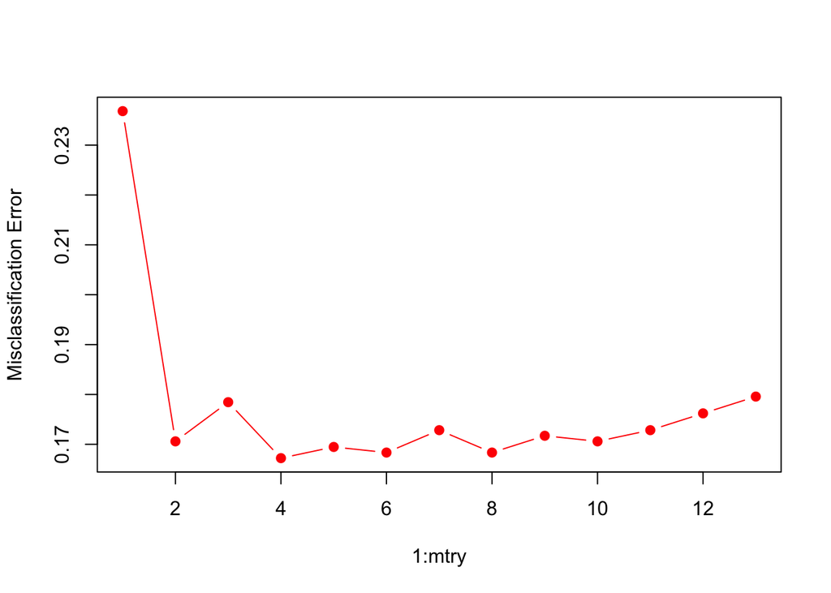

```r
# Plot error rate over mtry
matplot(1:mtry, oob.err, pch=19, col=c('red', 'blue'), type='b',
        ylab="Misclassification Error")
```

The ideal m-try value is usually the square root of the number of features used. In this case we have 15 features so an m-try value of 4 is reasonable. The error estimates are bumpy in our chart but an mtry value of 4 actually has our lowest error rate.

```r
# Build condition inference tree Random Forest
set.seed(1021)
## Best cforest model with .80 accuracy
cforest.fit <- cforest(as.factor(Survived) ~ Room + Cabin + Ticket + interact + numcabin+
                         Pclass + Sex + Age + SibSp + Parch + Fare + Embarked + Title
                       + FamilySize + FamilyID,
                       data = train, controls=cforest_unbiased(ntree=330, mtry=4))
# Now let's make a prediction
pred.cforest <- predict(cforest.fit, test, OOB=T, type = "response")
```

This model received a score of .79426 on the kaggle scoreboard. A marginal improvement but we’ll take it.

Let’s move on to one final ensemble model; gradient boosting. The gbm method has a few tuning parameters so we’ll use the train function in the caret package to find some good settings.

```r
set.seed(1021)
require(gbm)
fitControl <- trainControl(method = "repeatedcv", number=5, repeats=5)
gbmGrid <-  expand.grid(interaction.depth = c(6,12),
                        n.trees = c(100, 500),
                        shrinkage = c(0.001, 0.01),
                        n.minobsinnode = c(2,4))
gbm.train <- train(as.factor(Survived) ~ interact + numcabin + Room + Ticket+Cabin+
                   Pclass + Sex + Age + SibSp + Parch + Fare + Embarked + Title
                 + FamilySize + FamilyID, data = train,
                method = "gbm",
                trControl = fitControl,metric="Kappa", verbose = FALSE, tuneGrid=gbmGrid)
gbm.train
```

```
## Stochastic Gradient Boosting
##
## 891 samples
##  19 predictor
##   2 classes: '0', '1'
##
## No pre-processing
## Resampling: Cross-Validated (5 fold, repeated 5 times)
##
## Summary of sample sizes: 713, 712, 713, 712, 714, 713, ...
##
## Resampling results across tuning parameters:
##
##   shrinkage  interaction.depth  n.minobsinnode  n.trees  Accuracy
##   0.001       6                 2               100      0.6161646
##   0.001       6                 2               500      0.7992884
##   0.001       6                 4               100      0.6161646
##   0.001       6                 4               500      0.7981572
##   0.001      12                 2               100      0.6161646
##   0.001      12                 2               500      0.8253386
##   0.001      12                 4               100      0.6161646
##   0.001      12                 4               500      0.8230838
##   0.010       6                 2               100      0.8271086
##   0.010       6                 2               500      0.8365608
##   0.010       6                 4               100      0.8268902
##   0.010       6                 4               500      0.8343149
##   0.010      12                 2               100      0.8340624
##   0.010      12                 2               500      0.8399166
##   0.010      12                 4               100      0.8347365
##   0.010      12                 4               500      0.8387967
##   Kappa      Accuracy SD  Kappa SD
##   0.0000000  0.001771297  0.00000000
##   0.5398232  0.025670575  0.06556738
##   0.0000000  0.001771297  0.00000000
##   0.5363502  0.028400129  0.07214578
##   0.0000000  0.001771297  0.00000000
##   0.6060414  0.026118794  0.06319457
##   0.0000000  0.001771297  0.00000000
##   0.6007522  0.026647304  0.06484023
##   0.6206545  0.030633900  0.06762968
##   0.6492610  0.028666728  0.06189602
##   0.6192617  0.028136553  0.06242843
##   0.6445685  0.029587822  0.06330749
##   0.6353641  0.032163618  0.07365101
##   0.6558836  0.027054140  0.05912135
##   0.6369267  0.031162035  0.07160075
##   0.6535001  0.027203045  0.05958551
##
## Kappa was used to select the optimal model using  the largest value.
## The final values used for the model were n.trees = 500,
##  interaction.depth = 12, shrinkage = 0.01 and n.minobsinnode = 2.
```

We’ve got a rough idea what our parameters should be so now we’ll make another prediction vector.

```r
gbm.fit <- gbm(Survived ~ interact + numcabin + Room + Ticket+Cabin+
                   Pclass + Sex + Age + SibSp + Parch + Fare + Embarked + Title
                 + FamilySize + FamilyID, data = train, n.trees=2000, interaction.depth=12, shrinkage=0.01, n.minobsinnode=2)
```

```
## Distribution not specified, assuming bernoulli ...
```

```r
pred.gbm <- predict(gbm.fit, test, n.trees=1000, type='response')
pred.gbm[pred.gbm < .5] <- 0; pred.gbm[pred.gbm >= 0.5] <- 1
pred.gbm <- as.factor(pred.gbm)
```

This scored .7655 on Kaggle, slightly inferior to our other two models.

Finally, let’s blend the results from our three types of models together and take a simple majority vote. We’ll create a dataframe with the predictions from each model and then convert the class of each column to type integer so we can use operators. We’ll vectorize the results and then convert them back into the proper format of 0 and 1.

```r
## blend predictions together and take a vote
vote <- data.frame(pred.glm, pred.cforest, pred.gbm)
for ( i in 1:3 ) {
    vote[,i] <- as.integer(as.character(vote[,i]))
}
results <- vote[,1] + vote[,2] + vote[,3]
results[results == 1] <- 0
results[results >= 2] <- 1

submit <- data.frame(PassengerId = test$PassengerId, Survived = results)
```

This is our best model so far with a score of .799, a very slight improvement.